# Homework 4

Ceren Özkan

HOMEWORK 4

Note: All codes, plots and summaries are given at the end of the document. Note2: All data links are given in this RMD document. Files can also be found in my github master branch.

1 - For the first observation, Online News Popularity Dataset is used. You can achive the dataset from the following link: https://archive.ics.uci.edu/ml/datasets/Online+News+Popularity This dataset consists of 61 attributes and can be considered as regression dataset. From the codes below, you can see the testing results for all the methods. As a result, Lasso regression found to be the best as a classifying method. 2- To perform classification on categorical variables, Mushroom dataset (https://archive.ics.uci.edu/ml/datasets/Mushroom) is used. In this dataset there are 22 attributes which shows a different attribute of a mushroom. Using those categorical values, classification tools are tried. For this dataset, SGB and RF methods had an error rate of 0, which indicates a perfect clustering. If we consider it to be true, they work as best. Also, with the DT methods, different minbucket sizes and cps are tried and an optimal value for the best fit is found.

3- Nextly, Diabetes data (https://archive.ics.uci.edu/ml/datasets/Diabetes+130-US+hospitals+for+years+1999-2008) is examined.This data has 55 attributes which are mixed (consisting of both categorical and numeric data). For this method, different sized DT methods are tried and the lowest error rate is found in this method.

4- Lastly, default of credit card for clients dataset (https://archive.ics.uci.edu/ml/datasets/default+of+credit+card+clients) is observed. THis data set has a class imbalance problem, and the best fit is get with Lasso method.

GENERAL OBSERVATIONS:

- Firstly, I observed that for regression datas, Lasso classification works best, which is expected. Since other methods are types of clustering, penalized regression works better.
- For performance comparison, SGB is the slowest method. It performs a lot of iterations hence take a long time to get results. In clustering methods, Decision Trees works best since they do not interpret the whole data before seperation.
- Looking at the cross-validation results, they are consistent with each method. This shows that all methods work as expected, and they can be chosen as to satisfy the need.

```r
library(glmnet)
library(rpart)
library(rpart.plot)
library(randomForest)
library(caret)
library(stringr)
library(tidyverse)
library(readxl)


setwd("C:/Users/ceren/Desktop/Dersler/2020 Fall - MASTER/IE 582/HW4")


#DATA 1 -- Online News
OnlineNewsPopularity <- read_csv("OnlineNewsPopularity/OnlineNewsPopularity/OnlineNewsPopularity.csv")
OnlineNewsPopularity <- OnlineNewsPopularity[,-1]
str(OnlineNewsPopularity)  #all numeric
```

```
## tibble [39,644 x 60] (S3: tbl_df/tbl/data.frame)
##  $ timedelta                    : num [1:39644] 731 731 731 731 731 731 731 731 731 731 ...
##  $ n_tokens_title               : num [1:39644] 12 9 9 9 13 10 8 12 11 10 ...
##  $ n_tokens_content             : num [1:39644] 219 255 211 531 1072 ...
##  $ n_unique_tokens              : num [1:39644] 0.664 0.605 0.575 0.504 0.416 ...
##  $ n_non_stop_words             : num [1:39644] 1 1 1 1 1 ...
##  $ n_non_stop_unique_tokens     : num [1:39644] 0.815 0.792 0.664 0.666 0.541 ...
##  $ num_hrefs                    : num [1:39644] 4 3 3 9 19 2 21 20 2 4 ...
##  $ num_self_hrefs               : num [1:39644] 2 1 1 0 19 2 20 20 0 1 ...
##  $ num_imgs                     : num [1:39644] 1 1 1 1 20 0 20 20 0 1 ...
##  $ num_videos                   : num [1:39644] 0 0 0 0 0 0 0 0 0 1 ...
##  $ average_token_length         : num [1:39644] 4.68 4.91 4.39 4.4 4.68 ...
##  $ num_keywords                 : num [1:39644] 5 4 6 7 7 9 10 9 7 5 ...
##  $ data_channel_is_lifestyle    : num [1:39644] 0 0 0 0 0 0 1 0 0 0 ...
##  $ data_channel_is_entertainment: num [1:39644] 1 0 0 1 0 0 0 0 0 0 ...
```

[output cut: 46 more lines]

```r
table(OnlineNewsPopularity$shares)
```

```
##
##      1      4      5      8     22     23     28     35     36     41     42
##      1      1      1      1      2      1      2      1      1      1      2
##     43     44     45     47     48     49     50     51     52     53     54
##      2      1      1      1      2      3      2      1      1      1      1
##     56     57     58     59     60     63     64     65     66     67     70
##      1      3      1      2      2      1      3      2      1      1      2
##     74     76     77     78     80     81     82     83     84     85     86
##      1      1      3      2      2      1      4      1      1      1      2
##     87     88     89     90     91     92     93     95     97     98     99
##      1      3      2      1      2      1      1      2      2      1      2
##    100    102    103    104    106    109    110    111    112    114    115
##      1      1      1      1      1      2      1      2      2      1      1
##    116    119    121    123    124    127    128    129    130    134    135
##      3      2      2      2      1      1      1      2      1      1      1
```

[output cut: 252 more lines]

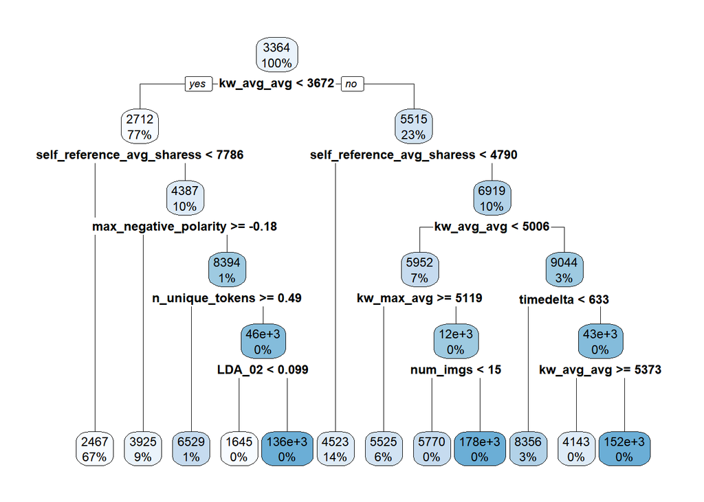

```r
#random split
smpsize <- floor(0.8 * nrow(OnlineNewsPopularity))
set.seed(123)
train_ind <- sample(seq_len(nrow(OnlineNewsPopularity)), size = smpsize)
traindata <- OnlineNewsPopularity[train_ind,]
testdata <- OnlineNewsPopularity[-train_ind,]

Lasso <- cv.glmnet(as.matrix(traindata), as.matrix(traindata$shares), family = "gaussian")
predLasso <- predict(Lasso,as.matrix(testdata))
RMSELasso <- RMSE(testdata$shares,predLasso)

DTree <- rpart(shares~., data = traindata, method = "anova", minbucket = 5, cp = 0.005)
rpart.plot(DTree)
```

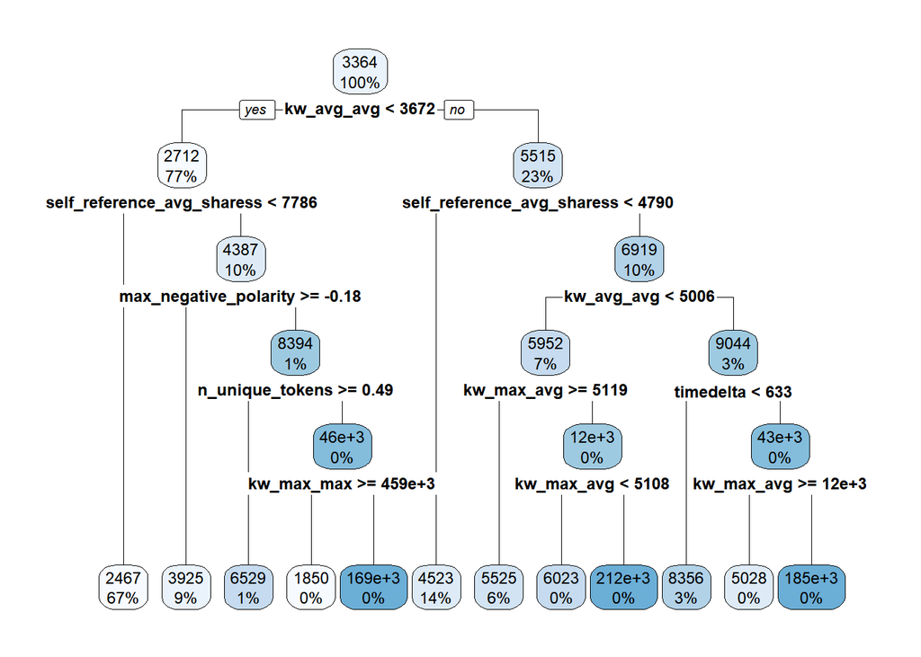

```r
predDTree <- predict(DTree, testdata)
RMSEDT1 <- RMSE(testdata$shares, predDTree)

DTree <- rpart(shares~., data = traindata, method = "anova", minbucket = 4, cp = 0.005)
rpart.plot(DTree)
```

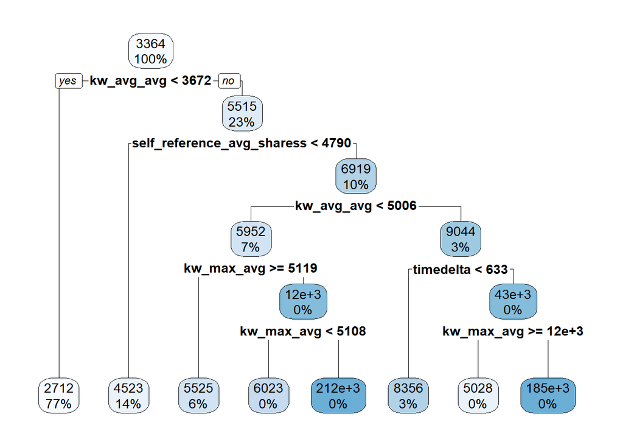

```r
predDTree <- predict(DTree, testdata)
RMSEDT2 <-RMSE(testdata$shares, predDTree)

DTree <- rpart(shares~., data = traindata, method = "anova", minbucket = 4, cp = 0.01)
rpart.plot(DTree)
```

```r
predDTree <- predict(DTree, testdata)
RMSEDT3 <-RMSE(testdata$shares, predDTree)

#Different values for minbucket and cp is tried. The best results (min MSE) is gathered with
#bucket size 4 and cp 0.005. If we decrease cp too much, that results in very complex trees however
#error rates are high. Hence, the best results are gained with these params.

fitControl <- trainControl(method = "cv", number = 5, verboseIter = TRUE, classProbs = TRUE)
tunegrid <- expand.grid(.mtry=c(3,5,10), .splitrule = "variance", .min.node.size = 5)
RF <- train(shares~., data=traindata, method="ranger", trControl = fitControl, tuneGrid = tunegrid)
predRF <- predict(RF, testdata)
RMSERF <-RMSE(testdata$shares, predRF)

tunegrid <-  expand.grid(interaction.depth = c(1, 5, 9),n.trees = (1:5)*50, shrinkage = c(0.05,0.01, 0.1),n.minobsinnode = 10)
SGB <- train(shares~., data=traindata, method="gbm", trControl = fitControl, tuneGrid = tunegrid)
predSGB <- predict(SGB, testdata)
RMSESGB <-RMSE(testdata$shares, predSGB)

TotalRMSE <- c(RMSELasso, RMSEDT1, RMSEDT2, RMSEDT3, RMSERF, RMSESGB)
TotalRMSE
```

```
## [1]   460.5803 14998.2077 14608.0784 14620.6749 14243.1486 14246.2824
```

```r
#According to this, Lasso is the best.


#DATA 2 - Mushroom
agaricus_lepiota <- read_delim("Mushrooms/agaricus-lepiota.csv", ";", escape_double = FALSE, col_types = cols(bruises = col_character(),`gill-attachment` = col_character()), trim_ws = TRUE)

newdata <- agaricus_lepiota
str(newdata) #categorical
```

```
## tibble [8,124 x 23] (S3: spec_tbl_df/tbl_df/tbl/data.frame)
##  $ cap-shape               : chr [1:8124] "x" "x" "b" "x" ...
##  $ cap-surface             : chr [1:8124] "s" "s" "s" "y" ...
##  $ cap-color               : chr [1:8124] "n" "y" "w" "w" ...
##  $ bruises                 : chr [1:8124] "t" "t" "t" "t" ...
##  $ odor                    : chr [1:8124] "p" "a" "l" "p" ...
##  $ gill-attachment         : chr [1:8124] "f" "f" "f" "f" ...
##  $ gill-spacing            : chr [1:8124] "c" "c" "c" "c" ...
##  $ gill-size               : chr [1:8124] "n" "b" "b" "n" ...
##  $ gill-color              : chr [1:8124] "k" "k" "n" "n" ...
##  $ stalk-shape             : chr [1:8124] "e" "e" "e" "e" ...
##  $ stalk-root              : chr [1:8124] "e" "c" "c" "e" ...
##  $ stalk-surface-above-ring: chr [1:8124] "s" "s" "s" "s" ...
##  $ stalk-surface-below-ring: chr [1:8124] "s" "s" "s" "s" ...
##  $ stalk-color-above-ring  : chr [1:8124] "w" "w" "w" "w" ...
##  $ stalk-color-below-ring  : chr [1:8124] "w" "w" "w" "w" ...
##  $ veil-type               : chr [1:8124] "p" "p" "p" "p" ...
##  $ veil-color              : chr [1:8124] "w" "w" "w" "w" ...
##  $ ring-number             : chr [1:8124] "o" "o" "o" "o" ...
##  $ ring-type               : chr [1:8124] "p" "p" "p" "p" ...
##  $ spore-print-color       : chr [1:8124] "k" "n" "n" "k" ...
##  $ population              : chr [1:8124] "s" "n" "n" "s" ...
##  $ habitat                 : chr [1:8124] "u" "g" "m" "u" ...
##  $ class                   : chr [1:8124] "p" "e" "e" "p" ...
##  - attr(*, "spec")=
##   .. cols(
##   ..   `cap-shape` = col_character(),
##   ..   `cap-surface` = col_character(),
##   ..   `cap-color` = col_character(),
##   ..   bruises = col_character(),
##   ..   odor = col_character(),
##   ..   `gill-attachment` = col_character(),
##   ..   `gill-spacing` = col_character(),
##   ..   `gill-size` = col_character(),
##   ..   `gill-color` = col_character(),
##   ..   `stalk-shape` = col_character(),
##   ..   `stalk-root` = col_character(),
##   ..   `stalk-surface-above-ring` = col_character(),
##   ..   `stalk-surface-below-ring` = col_character(),
##   ..   `stalk-color-above-ring` = col_character(),
##   ..   `stalk-color-below-ring` = col_character(),
##   ..   `veil-type` = col_character(),
##   ..   `veil-color` = col_character(),
##   ..   `ring-number` = col_character(),
##   ..   `ring-type` = col_character(),
##   ..   `spore-print-color` = col_character(),
##   ..   population = col_character(),
##   ..   habitat = col_character(),
##   ..   class = col_character()
##   .. )
```

```r
sum(is.na(newdata))
```

```
## [1] 0
```

```r
table(newdata$class)
```

```
##
##    e    p
## 4208 3916
```

```r
character_vars <- lapply(newdata, class) == "character"
newdata[, character_vars] <- lapply(newdata[, character_vars], as.factor)
str(newdata)
```

```
## tibble [8,124 x 23] (S3: spec_tbl_df/tbl_df/tbl/data.frame)
##  $ cap-shape               : Factor w/ 6 levels "b","c","f","k",..: 6 6 1 6 6 6 1 1 6 1 ...
##  $ cap-surface             : Factor w/ 4 levels "f","g","s","y": 3 3 3 4 3 4 3 4 4 3 ...
##  $ cap-color               : Factor w/ 10 levels "b","c","e","g",..: 5 10 9 9 4 10 9 9 9 10 ...
##  $ bruises                 : Factor w/ 2 levels "f","t": 2 2 2 2 1 2 2 2 2 2 ...
##  $ odor                    : Factor w/ 9 levels "a","c","f","l",..: 7 1 4 7 6 1 1 4 7 1 ...
##  $ gill-attachment         : Factor w/ 2 levels "a","f": 2 2 2 2 2 2 2 2 2 2 ...
##  $ gill-spacing            : Factor w/ 2 levels "c","w": 1 1 1 1 2 1 1 1 1 1 ...
##  $ gill-size               : Factor w/ 2 levels "b","n": 2 1 1 2 1 1 1 1 2 1 ...
##  $ gill-color              : Factor w/ 12 levels "b","e","g","h",..: 5 5 6 6 5 6 3 6 8 3 ...
##  $ stalk-shape             : Factor w/ 2 levels "e","t": 1 1 1 1 2 1 1 1 1 1 ...
##  $ stalk-root              : Factor w/ 5 levels "?","b","c","e",..: 4 3 3 4 4 3 3 3 4 3 ...
##  $ stalk-surface-above-ring: Factor w/ 4 levels "f","k","s","y": 3 3 3 3 3 3 3 3 3 3 ...
##  $ stalk-surface-below-ring: Factor w/ 4 levels "f","k","s","y": 3 3 3 3 3 3 3 3 3 3 ...
##  $ stalk-color-above-ring  : Factor w/ 9 levels "b","c","e","g",..: 8 8 8 8 8 8 8 8 8 8 ...
##  $ stalk-color-below-ring  : Factor w/ 9 levels "b","c","e","g",..: 8 8 8 8 8 8 8 8 8 8 ...
##  $ veil-type               : Factor w/ 1 level "p": 1 1 1 1 1 1 1 1 1 1 ...
##  $ veil-color              : Factor w/ 4 levels "n","o","w","y": 3 3 3 3 3 3 3 3 3 3 ...
##  $ ring-number             : Factor w/ 3 levels "n","o","t": 2 2 2 2 2 2 2 2 2 2 ...
##  $ ring-type               : Factor w/ 5 levels "e","f","l","n",..: 5 5 5 5 1 5 5 5 5 5 ...
##  $ spore-print-color       : Factor w/ 9 levels "b","h","k","n",..: 3 4 4 3 4 3 3 4 3 3 ...
##  $ population              : Factor w/ 6 levels "a","c","n","s",..: 4 3 3 4 1 3 3 4 5 4 ...
##  $ habitat                 : Factor w/ 7 levels "d","g","l","m",..: 6 2 4 6 2 2 4 4 2 4 ...
##  $ class                   : Factor w/ 2 levels "e","p": 2 1 1 2 1 1 1 1 2 1 ...
##  - attr(*, "spec")=
##   .. cols(
##   ..   `cap-shape` = col_character(),
##   ..   `cap-surface` = col_character(),
##   ..   `cap-color` = col_character(),
##   ..   bruises = col_character(),
##   ..   odor = col_character(),
##   ..   `gill-attachment` = col_character(),
##   ..   `gill-spacing` = col_character(),
##   ..   `gill-size` = col_character(),
##   ..   `gill-color` = col_character(),
##   ..   `stalk-shape` = col_character(),
##   ..   `stalk-root` = col_character(),
##   ..   `stalk-surface-above-ring` = col_character(),
##   ..   `stalk-surface-below-ring` = col_character(),
##   ..   `stalk-color-above-ring` = col_character(),
##   ..   `stalk-color-below-ring` = col_character(),
##   ..   `veil-type` = col_character(),
##   ..   `veil-color` = col_character(),
##   ..   `ring-number` = col_character(),
##   ..   `ring-type` = col_character(),
##   ..   `spore-print-color` = col_character(),
##   ..   population = col_character(),
##   ..   habitat = col_character(),
##   ..   class = col_character()
##   .. )
```

```r
#since veil-type only has 1 factor, we should omit
newdata <- newdata[,c(-16)]

smpsize2 <- floor(0.7 * nrow(newdata))
set.seed(123)
train_ind2 <- sample(seq_len(nrow(newdata)), size = smpsize2)
traindata2 <- newdata[train_ind2,]
testdata2 <- newdata[-train_ind2,]

fitControl <- trainControl(method = "cv", number = 5, verboseIter = TRUE, classProbs = TRUE)
tunegrid <- expand.grid(alpha = 1,lambda = seq(0.001,0.1,by = 0.001))
Lasso2 <- train(class~., data=traindata2, method="glmnet", trControl = fitControl, tuneGrid = tunegrid)
```

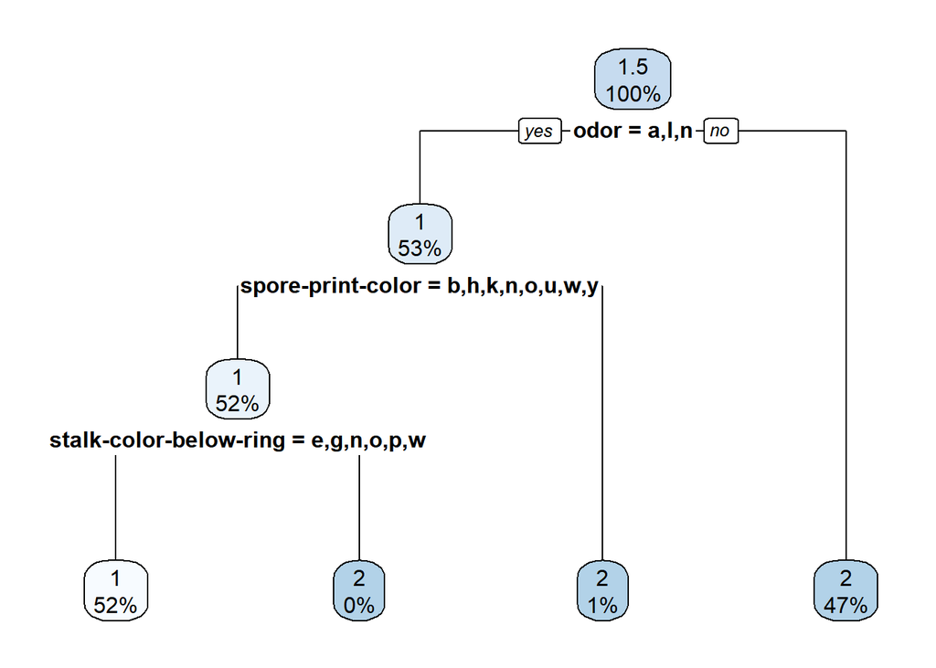

```r
predLasso2 <- predict(Lasso2,as.matrix(testdata2))
RMSELasso2 <- RMSE(as.numeric(testdata2$class),as.numeric(predLasso2))

DTree2 <- rpart(class~., data = traindata2, method = "anova", minbucket = 5, cp = 0.005)
rpart.plot(DTree2)
```

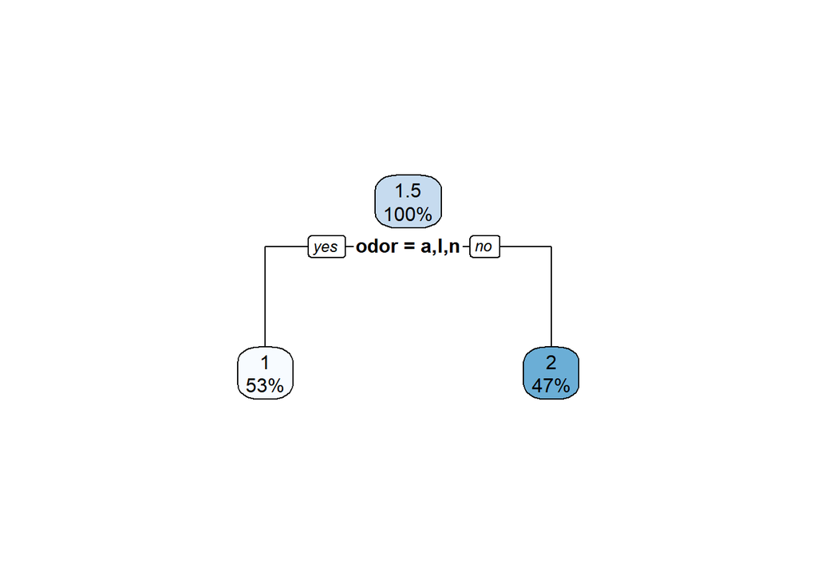

```r
predDTree2 <- predict(DTree2, testdata2)
RMSEDT21 <- RMSE(as.numeric(testdata2$class),as.numeric(predDTree2))

DTree2 <- rpart(class~., data = traindata2, method = "anova", minbucket = 4, cp = 0.005)
rpart.plot(DTree2)
predDTree2 <- predict(DTree2, testdata2)
RMSEDT22 <-RMSE(as.numeric(testdata2$class),as.numeric(predDTree2))

DTree2 <- rpart(class~., data = traindata2, method = "anova", minbucket = 2, cp = 0.5)
rpart.plot(DTree2)
```

```r
predDTree2 <- predict(DTree2, testdata2)
RMSEDT23 <-RMSE(as.numeric(testdata2$class),as.numeric(predDTree2))
#as observed, optimal tree is found with 3 decision points and has a error rate of approx. 0.06

tunegrid <- expand.grid(.mtry=c(3,5,10), .splitrule = "gini", .min.node.size = 5)
RF2 <- train(class~., data=traindata2, method="ranger", trControl = fitControl, tuneGrid = tunegrid)
predRF2 <- predict(RF2, testdata2)
RMSERF2 <-RMSE(as.numeric(testdata2$class),as.numeric(predRF2))

tunegrid <-  expand.grid(interaction.depth = c(1, 5, 9),n.trees = (1:5)*50, shrinkage = c(0.05,0.01, 0.1),n.minobsinnode = 10)
SGB2 <- train(class~., data=traindata2, method="gbm", trControl = fitControl, tuneGrid = tunegrid)
predSGB2 <- predict(SGB2, testdata2)
RMSESGB2 <-RMSE(as.numeric(testdata2$class),as.numeric(predSGB2))

TotalRMSE2 <- c(RMSELasso2, RMSEDT21, RMSEDT22, RMSEDT23, RMSERF2, RMSESGB2)
TotalRMSE2
```

```
## [1] 0.02864166 0.06056152 0.06056152 0.11985146 0.00000000 0.00000000
```

```r
#DATA 3 - Diabetes
diabetic_data <- read_csv("dataset_diabetes/dataset_diabetes/diabetic_data.csv")

idx <- diabetic_data == "?"
is.na(diabetic_data) <- idx
sum(is.na(diabetic_data))
```

```
## [1] 192849
```

```r
diabetic_data <- na.omit(diabetic_data)
table(diabetic_data$readmitted)
```

```
##
## <30 >30  NO
## 100 478 465
```

```r
diabetic_data$readmitted <- str_replace(as.character(diabetic_data$readmitted), "<30", "YES")
diabetic_data$readmitted <- str_replace(as.character(diabetic_data$readmitted), ">30", "YES")
table(diabetic_data$readmitted)
```

```
##
##  NO YES
## 465 578
```

```r
newdata <- diabetic_data
character_vars <- lapply(newdata, class) == "character"
newdata[, character_vars] <- lapply(newdata[, character_vars], as.factor)
str(newdata)
```

```
## tibble [1,043 x 50] (S3: tbl_df/tbl/data.frame)
##  $ encounter_id            : num [1:1043] 88792836 88986678 89032962 89191392 89277516 ...
##  $ patient_nbr             : num [1:1043] 1.01e+08 5.87e+07 6.93e+07 6.20e+07 3.10e+07 ...
##  $ race                    : Factor w/ 4 levels "AfricanAmerican",..: 3 3 3 3 3 3 3 3 3 3 ...
##  $ gender                  : Factor w/ 2 levels "Female","Male": 1 2 2 2 2 1 2 2 2 1 ...
##  $ age                     : Factor w/ 10 levels "[0-10)","[10-20)",..: 8 9 7 5 6 8 7 6 8 8 ...
##  $ weight                  : Factor w/ 8 levels "[0-25)","[100-125)",..: 8 7 2 8 2 8 7 2 2 8 ...
##  $ admission_type_id       : num [1:1043] 3 1 1 1 3 1 1 1 3 1 ...
##  $ discharge_disposition_id: num [1:1043] 3 11 1 3 1 3 1 1 1 1 ...
##  $ admission_source_id     : num [1:1043] 1 5 7 7 1 7 7 7 1 7 ...
##  $ time_in_hospital        : num [1:1043] 10 6 2 3 2 10 3 4 2 3 ...
##  $ payer_code              : Factor w/ 11 levels "BC","CM","CP",..: 10 10 3 4 1 6 3 1 6 10 ...
##  $ medical_specialty       : Factor w/ 8 levels "Cardiology","Dentistry",..: 8 3 1 7 8 4 1 8 8 1 ...
##  $ num_lab_procedures      : num [1:1043] 65 73 58 33 5 63 75 46 1 50 ...
##  $ num_procedures          : num [1:1043] 1 0 3 0 4 0 2 1 1 0 ...
```

[output cut: 38 more lines]

```r
newdata <- newdata[, sapply(newdata, nlevels) > 1]

smpsize3 <- floor(0.8 * nrow(newdata))
set.seed(123)
train_ind3 <- sample(seq_len(nrow(newdata)), size = smpsize3)
traindata3 <- newdata[train_ind3,]
testdata3 <- newdata[-train_ind3,]


fitControl <- trainControl(method = "cv", number = 5, verboseIter = TRUE, classProbs = TRUE)
tunegrid <- expand.grid(alpha = 1,lambda = seq(0.001,0.1,by = 0.001))
Lasso3 <- train(readmitted~., data=traindata3, method="glmnet", trControl = fitControl, tuneGrid = tunegrid)
```